# **Лабораторна робота №1**

**Тема:**Робота з OpenCV у середовищі Anaconda

**Мета:**quick start для роботи з бібліотекою з відкритим кодом для комп’ютерного зору та обробки зображень OpenCV у середовищі Anaconda із застосуванням Jupyter Notebook засобами мови програмування Python.

## Завдання для самостійної роботи

1. Завантажити і встановити збірку Python Anaconda.

[figure not shown]

2. Через інтерфейс командного рядка налаштувати за допомогою **conda** віртуальне середовище з ім’ям *<StudentLastName>_OpenCV*. Етапи роботи підтвердити скріншотами.

[figure not shown]

3. Проінсталювати в створене середовище пакети, необхідні для роботи з OpenCV.

[figure not shown]

4. Створити Notebook-документ *<lab_1_StudentLastName>* за допомогою Jupyter Notebook.

[figure not shown]

5. Відобразити в робочому документі (“зошиті” ipython) виконання пунктів 1-3 індивідуального завдання.
6. Сфотографувати себе на камеру і виконати імпорт і візуалізацію кольорового та напівтонового зображення у робочий документ.
7. Виконати переведення кольорового зображення у напівтонове і записати його на диск.

```
version cv2: 4.12.0
Shape/Dimensions: (2560, 2560, 3)
Number of pixels: 19660800
```

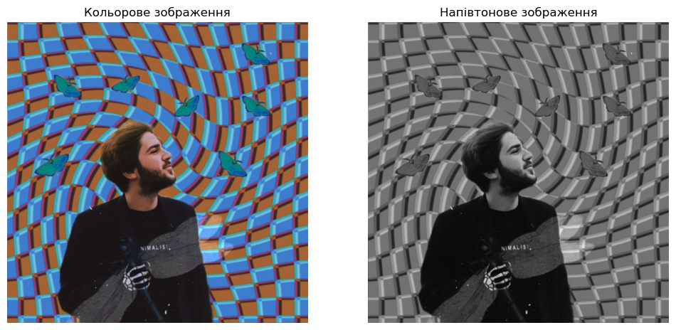

```
Сіре зображення збережено.
```

```python
import numpy as np
import cv2 as cv
from matplotlib import pyplot as plt
print(f'version cv2: {cv.__version__}')
image = cv.imread('src/photo.png')
if image is None:
    print("Помилка: Файл не знайдено або шлях невірний.")
else:
    print(f'Shape/Dimensions: {image.shape}')
    print(f'Number of pixels: {image.size}')
    gray = cv.cvtColor(image, cv.COLOR_BGR2GRAY)
    image_rgb = cv.cvtColor(image, cv.COLOR_BGR2RGB)

    plt.figure(figsize=(12, 6))
    plt.subplot(1, 2, 1)
    plt.imshow(image_rgb)
    plt.title('Кольорове зображення')
    plt.axis('off')
    plt.subplot(1, 2, 2)
    plt.imshow(gray, cmap='gray')
    plt.title('Напівтонове зображення')
    plt.axis('off')
    plt.show()
    cv.imwrite('src/photo_gray.png', gray)
    print("Сіре зображення збережено.")
```

Контрольні запитання

Що таке pip і conda та чим вони відрізняються між собою? pip — це стандартний менеджер пакетів для Python, який встановлює модулі з PyPI. conda — це більш розширена система, що відповідає не тільки за встановлення Python-бібліотек, а й за керування середовищами та залежностями інших мов. Основна різниця в тому, що pip працює тільки з Python-пакетами, тоді як conda формує цілі робочі середовища й контролює сумісність системних компонентів.

Як буде виглядати виконання пунктів 1-3 індивідуального завдання за допомогою Virtualenv? Створення окремого середовища:python -m venv myenv Запуск середовища через скрипт активації:myenv\Scripts\activate Встановлення потрібних пакетів:pip install numpy matplotlib opencv-python jupyter Запуск Jupyter Notebook:jupyter notebook

Як виконати візуалізацію зображення (див. п.3) засобами matplotlib? Оскільки OpenCV відкриває зображення у форматі BGR, перед показом у Matplotlib потрібно перетворити його до RGB.

import cv2 import matplotlib.pyplot as plt

Зчитуємо та змінюємо порядок кольорів image = cv2.imread('src/Color.png') image_rgb = cv2.cvtColor(image, cv2.COLOR_BGR2RGB)

Виводимо на екран plt.imshow(image_rgb) plt.title("Кольорове зображення") plt.axis("off") plt.show()

Як виконати компіляцію вхідного документа Jupyter Notebook із його середовища, не використовуючи інтерфейс командного рядка? Для цього достатньо скористатися меню самого ноутбука: у верхній панелі виберіть File → Download as, після чого можна зберегти документ у форматі PDF, HTML чи іншому варіанті без застосування терміналу.